# C4_tensor

## Redes neuronales

### Clase9: Redes neuronales

**Autor: Luis Fernando Apáez Álvarez**

#### Contenido

Algunas consideraciones

Definiendo una red neuronal con keras

Entrenamiento y validación

### Algunas consideraciones

Sabemos que la inicialización de los pesos es de manera aleatoria, y de hecho hay algunos caminos específicos para hacerlo. Por ejemplo, inicializaremos los pesos de manera aleatoria que siguen una distribución normal:

```python
# Enfoque de bajo nivel
import tensorflow as tf

# Definimos 500x500 variable aleatoria normal
pesos1 = tf.Variable(tf.random.normal([500,500]))

# Definimos 500x500 variable aletoria normal truncada
# la cual descarta sorteos muy grandes o muy pequenios
pesos2 = tf.Variable(tf.random.truncated_normal([500,500]))
```

También, podemos utilizar un enfoque de alto nivel inicializando un capa densa:

```python
# capa densa con el inicializador por defecto
dense1 = tf.keras.layers.Dense(32, activation='relu')

# capa densa inicializada con ceros
dense2 = tf.keras.layers.Dense(32, activation='relu', kernel_initializer='zeros')
```

Viendo así algunas alternativas para la inicialización de los pesos desde un punto de vista de alto y bajo nivel.

Otro problema con el cual nos podemos encontrar a la hora de programar una red neuronal es el sobreajuste. Una manera de mitigarlo es utilizando `droput`, la cual es una operación que aleatoriamente "suelta" los pesos conectados con ciertos nodos en una capa durante el proceso del entrenamiento. Lo anterior hará que el rendimiento de nuestra red sea mejor. Por ejemplo

```
import numpy as np

# Definimos los datos de entrada
inputs = np.array(data, np.float32)

# capa de entrada
dense1 = tf.keras.layers.Dense(32, activation='relu')(inputs)

# capa 2
dense2 = tf.keras.layers.Dense(16, activation='relu')(dense1)

# aplicamos la operacion dropout
# donde descartaremos aleatoriamente los pesos conectados
# al 25% de los nodos de la segunga capa
dropout1 = tf.keras.layers.Dropout(0.25)(dense2)

# Capa de salida
output = tf.keras.layers.Dense(1, activation='sigmoid')(dropout1)
```

### Definiendo una red neuronal con keras

Para trabajar con redes neuronales utilizando keras, estaremos utilizando el conjunto de datos MNIST, con lo cual buscaremos clasificar cuatro letras del lenguaje de señas: a, b, c y d. Para ello comenzaremos:

```python
# importacion necesaria
import pandas as pd
from tensorflow import keras

# Definimos el modelo secuencial
model = keras.Sequential()

# Cargamos los datos
data =  pd.read_csv('slmnist.csv', header=None)
data.head()
```

|  | 0 | 1 | 2 | 3 | 4 | 5 | 6 | 7 | 8 | 9 | ... | 775 | 776 | 777 | 778 | 779 | 780 | 781 | 782 | 783 | 784 |
| --- | --- | --- | --- | --- | --- | --- | --- | --- | --- | --- | --- | --- | --- | --- | --- | --- | --- | --- | --- | --- | --- |
| 0 | 1 | 142 | 143 | 146 | 148 | 149 | 149 | 149 | 150 | 151 | ... | 0 | 15 | 55 | 63 | 37 | 61 | 77 | 65 | 38 | 23 |
| 1 | 0 | 141 | 142 | 144 | 145 | 147 | 149 | 150 | 151 | 152 | ... | 173 | 179 | 179 | 180 | 181 | 181 | 182 | 182 | 183 | 183 |
| 2 | 1 | 156 | 157 | 160 | 162 | 164 | 166 | 169 | 171 | 171 | ... | 181 | 197 | 195 | 193 | 193 | 191 | 192 | 198 | 193 | 182 |
| 3 | 3 | 63 | 26 | 65 | 86 | 97 | 106 | 117 | 123 | 128 | ... | 175 | 179 | 180 | 182 | 183 | 183 | 184 | 185 | 185 | 185 |
| 4 | 1 | 156 | 160 | 164 | 168 | 172 | 175 | 178 | 180 | 182 | ... | 108 | 107 | 106 | 110 | 111 | 108 | 108 | 102 | 84 | 70 |

5 rows × 785 columns

Veamos ahora cómo se ven los datos almacenado en el dataframe anterior, donde cada fila es la representación de una imagen. Para ver dicha imagen haremos lo siguiente (antes de ello, se recomienda ver primero el siguiente apunte para aprender como convertir arrays en imágenes mediante arrays numpy: [Link](https://cursopypagina.github.io/CursoPy/Clases/Tarea_7_sol.html))

```python
# importaciones necesarias
import numpy as np
from PIL import Image

# Definimos una funcion
def to_image(fila):
    # dada una fila del dataframe data, convertimos
    # todos los valores de dicha fila en un array numpy
    array = np.array(data.iloc[fila][1:])
    # Cambiamos la forma del array y especificamos el tipo de dato
    # de entero de 8 bits (para asi poder convertir el array a imagen)
    # Donde colocaremos la dimension de los arrays en 28x28, puesto que
    # las imagenes que usaremos son de 28 pixeles por 28 pixeles
    array = np.array(array.reshape((28, 28)), dtype='uint8')
    # Convertimos el array a imagen
    img = Image.fromarray(array)
    # Cambiamos la dimension de la imagen
    img = img.resize((128,128))
    # mostramos la imagen
    display(img)
```

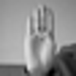

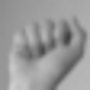

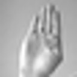

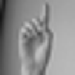

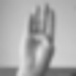

```python
# Veamos algunos ejemplos
for i in range(5):
    to_image(i)
```

Continuando, lo que haremos será definir la red neuronal

```python
# Definimos la primer capa, la cual es una capa densa con 16 nodos. Ademas
# especificamos la forma (shape) de los datos de entrada
model.add(keras.layers.Dense(16, activation='relu', input_shape=(28*28,)))
```

```python
# definimos una capa oculta con 8 nodos
model.add(keras.layers.Dense(8, activation='relu'))

# Especificamos la capa de salida con 4 nodos
model.add(keras.layers.Dense(4, activation='softmax'))
```

donde se ha especificado 4 nodos de salida dado que nos interesa clasificar las imágenes que representen la letra a, b, c y d (4 letras). Además, la función de activación para la capa de salida es softmax, la cual nos sirve para problemas de clasificación multiclase. Procedemos después a compilar el modelo

```python
#           optimizador | funcion de perdida para problemas
#                       | de clasificacion con mas de dos
#                       | clases
model.compile('adam',   loss='categorical_crossentropy')

# Resumen dle modelo
model.summary()
```

```
Model: "sequential"
_________________________________________________________________
 Layer (type)                Output Shape              Param #
=================================================================
 dense_2 (Dense)             (None, 16)                12560

 dense_3 (Dense)             (None, 8)                 136

 dense_4 (Dense)             (None, 4)                 36

=================================================================
Total params: 12,732
Trainable params: 12,732
Non-trainable params: 0
_________________________________________________________________
```

Por otro lado, consideremos el caso en el que deseamos entrenar dos modelos de manera conjunta para predecir el mismo objetivo

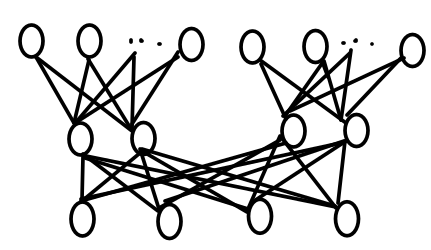

Para ello utilizaremos la api funcional. Consideremos el ejemplo de las imágenes, y supongamos que tenemos un conjunto de datos con 10 características

```python
# capa de entrada para el modelo 1
model1_inputs = tf.keras.Input(shape=(28*28,))

# capa de entrada para el modelo 2
model2_inputs = tf.keras.Input(shape=(10,))
```

y queremos utilizar ambos para predecir la clase de la imagen, pero restringir cómo interactúan en el modelo conjunto. Después

```python
# Capa 1 para el modelo 1
model1_layer1 = tf.keras.layers.Dense(12, activation='relu')(model1_inputs)

# Capa 2 para el modelo 1
model1_layer2 = tf.keras.layers.Dense(4, activation='softmax')(model1_layer1)

# Capa 1 para el modelo 2
model2_layer1 = tf.keras.layers.Dense(8, activation='relu')(model2_inputs)

# Capa 2 para el modelo 2
model2_layer2 = tf.keras.layers.Dense(4, activation='softmax')(model2_layer1)
```

Luego, definimos la capa donde uniremos los modelos:

```python
# union de los modelos 1 y 2
merged = tf.keras.layers.add([model1_layer2, model2_layer2])

# definimos el modelo funcional
#                                  entradas de cada red       salida conjunta
model = tf.keras.Model(inputs=[model1_inputs, model2_inputs], outputs=merged)

# compilamos el modelo
model.compile('adam', loss='categorical_crossentropy')
```

### Entrenamiento y validación

Normalmente realizaremos los siguientes pasos:

1. Cargar y limpiar los datos.
2. Definición del modelo a ocupar (especificando la arquitectura).
3. Entrenamiento y validación del modelo.
4. Evaluación.

Por ejemplo

```python
# importacion necesaria
import pandas as pd
import tensorflow as tf

# Definimos el modelo secuencial
model = tf.keras.Sequential()

# Cargamos los datos
data =  pd.read_csv('slmnist.csv', header=None)
```

Luego, agregamos una capa densa al modelo con 16 nodos

```python
model.add(tf.keras.layers.Dense(16, activation='relu', input_shape=(784, )))
```

Proseguimos definiendo la capa de salida con 4 nodos y una función de activación softmax

```python
model.add(tf.keras.layers.Dense(4, activation='softmax'))
```

Después, compilamos el modelo utilizando una función de pérdida de entropía cruzada y el optimizador Adam

```python
# agregamos el parametro de metrics para observar la precision
# a la hora del entrenamiento
model.compile('adam', loss='categorical_crossentropy', metrics=['accuracy'])
```

Definimos las variables `X` y `y`:

```python
import numpy as np

# Caracteristicas
X = np.array(data[[i for i in range(1,785)]])
X
```

```
array([[142, 143, 146, ...,  65,  38,  23],
       [141, 142, 144, ..., 182, 183, 183],
       [156, 157, 160, ..., 198, 193, 182],
       ...,
       [177, 179, 180, ..., 239, 233, 240],
       [121, 129, 138, ..., 197, 198, 211],
       [178, 178, 178, ..., 195, 194, 192]], dtype=int64)
```

Depues, si consideramos la variable `y` como sigue

```python
# Variable objetivo
y = np.array(data[0]).reshape(-1,1)
y
```

```
array([[1],
       [0],
       [1],
       ...,
       [2],
       [3],
       [2]], dtype=int64)
```

Tendremos un problema pues la clasificación será multiclase, para lo cual nuestra variable objetivo debe ser de la forma

- `[1, 0 , 0, 0]`: si la imagen corresponde a la categoría 0
- `[0, 1 , 0, 0]`: si la imagen corresponde a la categoría 1
- `[0, 0 , 1, 0]`: si la imagen corresponde a la categoría 2
- `[0, 0 , 0, 1]`: si la imagen corresponde a la categoría 3

Dicha transformación la lograremos mediante `OneHotEncoder` (codifica características categóricas como una matriz numérica única). Para ello escribimos

```python
# Ajuste del one hot encoder sobre la variable y
from sklearn.preprocessing import OneHotEncoder
enc = OneHotEncoder(handle_unknown='ignore')
enc.fit(y)
```

```
OneHotEncoder(handle_unknown='ignore')
```

```python
# transformamos la variable y desplegando el array
# como se menciono antes de acuerdo a las categorias
y_enc = enc.transform(y).toarray()
y_enc
```

```
array([[0., 1., 0., 0.],
       [1., 0., 0., 0.],
       [0., 1., 0., 0.],
       ...,
       [0., 0., 1., 0.],
       [0., 0., 0., 1.],
       [0., 0., 1., 0.]])
```

```python
# Dimension de las variables en cuestion
print(X.shape)
print(y_enc.shape)
```

```
(2000, 784)
(2000, 4)
```

Procedemos a entrenar el modelo

```python
# el entrenamiento se realizara a 10 epocas dividiendo los datos
# en 20% para validacion y 80% para entrenamiento
model.fit(X, y_enc, epochs=10, validation_split = 0.2)
```

```
<keras.callbacks.History at 0x23d4b132850>
```

```python
model.evaluate(X, y_enc)
```

```
[0.18859298527240753, 0.940500020980835]
```

Podemos ver un ejemplo de predicción:

```python
# Tomamos la primer imagen
X_1 = X[0].reshape(1, 784)
X_1.shape
```

```
(1, 784)
```

```python
# Realizamos la predicion

model.predict(X_1).round()
```

```
array([[0., 1., 0., 0.]], dtype=float32)
```

De donde se ha predicho que la categoría es la 1. En efecto:

```python
# La categoria asociada es la uno
data.iloc[0]
```

```
0        1
1      142
2      143
3      146
4      148
      ...
780     61
781     77
782     65
783     38
784     23
Name: 0, Length: 785, dtype: int64
```

El ejemplo anterior es muy sencillo, pues recordemos que debemos dividir los datos para el entrenmaiento y la prueba, lo cual no hicimos.

Por otro lado, trabajaremos con la API de estimadores, la cual es un submódulo de Tensorflow de alto nivel. Dicho submódulo es menos flexible, no obstante, aplica un conjunto de mejores prácticas al imponer restricciones en la arquitectura y el entrenamiento del modelo.

Además, la ventaja de utilizar dicho submódulo es que se pueden especificar, entrenar, evaluar e implementar modelos con menos líneas de código. Adicionalmente, hay modelos prefabricados que ya vienen incluidos, donde solo bastará con modificar algunos valores de parámetros.

Para las especificaciones del modelo haremos:

- Definimos las características.
- Cargamos y transformamos los datos dentro de una función. La salida de dicha función será un objeto diccionario de características y etiquetas.
- Se define un estimador. Donde hay ya estimadores prefabricados, o también podemos definir estimadores personalizados.
- Entrenamiento del modelo.

Veamos un ejemplo de lo anterior:

```python
# Definimos las caracteristicas numericas
# como una lista
features_list = [tf.feature_column.numeric_column('image', shape=(784, ))]
```

```python
# Definimos una funcion para cargar y transformar los datos

def input_fn():
    # Definimos un diccionario de las caracteristicas
    features = {'image': X}
    # Definimos las etiquetas
    labels = y
    # Retornamos
    return features, labels
```

```python
# Definimos el estimador que queremos entrenar
# hidden_units: cantidad de nodos por capa
# DNNClassifier: red neuronal profunda para la clasificacion
# DNNRegressor: red neuronal profunda para prediccion de valores continuos
model0 = tf.estimator.DNNClassifier(feature_columns=features_list,
                                    hidden_units=[32, 16, 8],
                                    n_classes=4)

# Entrenamiento del modelo
model0.train(input_fn, steps=20)
```

[output not shown]

```
<tensorflow_estimator.python.estimator.canned.dnn.DNNClassifierV2 at 0x23d4b0b99a0>
```

```python
result = model0.evaluate(input_fn, steps=20)

for key, value in result.items():
    print(key, ":", value)
```

```
INFO:tensorflow:Calling model_fn.
INFO:tensorflow:Done calling model_fn.
INFO:tensorflow:Starting evaluation at 2022-11-14T10:40:26
INFO:tensorflow:Graph was finalized.
INFO:tensorflow:Restoring parameters from C:\Users\usuario\AppData\Local\Temp\tmpi7fn7f9_\model.ckpt-20
INFO:tensorflow:Running local_init_op.
INFO:tensorflow:Done running local_init_op.
INFO:tensorflow:Evaluation [2/20]
INFO:tensorflow:Evaluation [4/20]
INFO:tensorflow:Evaluation [6/20]
INFO:tensorflow:Evaluation [8/20]
INFO:tensorflow:Evaluation [10/20]
INFO:tensorflow:Evaluation [12/20]
INFO:tensorflow:Evaluation [14/20]
INFO:tensorflow:Evaluation [16/20]
INFO:tensorflow:Evaluation [18/20]
INFO:tensorflow:Evaluation [20/20]
INFO:tensorflow:Inference Time : 0.48490s
INFO:tensorflow:Finished evaluation at 2022-11-14-10:40:26
INFO:tensorflow:Saving dict for global step 20: accuracy = 0.3705, average_loss = 2.0157855, global_step = 20, loss = 2.0157855
INFO:tensorflow:Saving 'checkpoint_path' summary for global step 20: C:\Users\usuario\AppData\Local\Temp\tmpi7fn7f9_\model.ckpt-20
accuracy : 0.3705
average_loss : 2.0157855
loss : 2.0157855
global_step : 20
```